# Assignment1

# 3. MS 1.14 - pg 8

### National Bridge Inventory. All highway bridges in the United States are inspected periodically for structural deficiency by the Federal Highway Administration (FHWA). Data from the FHWA inspections are compiled into the National Bridge Inventory (NBI). Several of the nearly 100 variables maintained by the NBI are listed below. Classify each variable as quantitative or qualitative.

1. Length of maximum span (feet): QUANTITATIVE
2. Number of vehicle lanes: QUANTITATIVE
3. Toll bridge (yes or no): QUALITATIVE
4. Average daily traffic: QUANTITATIVE
5. Condition of deck (good, fair, or poor): QUALITATIVE
6. Bypass or detour length (miles): QUANTITATIVE
7. Route type (interstate, U.S., state, county, or city): QUALITATIVE

# 4. MS page 12,13 Read pages 12 and 13 about random sampling designs and answer the following:

### (a) What are the names of the four random sampling designs (1 simple and 3 more complex).

### (b) Give a brief description of each.

# 5. MS 1.15 - pg 15 – Use sample(…,replace=FALSE), if mtbe is the dataframe then we need a random sample of the rows. If v is a vector containing a random sample of row indices then mtbe[v,] will be the random sample.

# 12. MS 2.73 - pg 70

# 13. MS 2.80 - pg 72

### Mongolian desert ants. The Journal of Biogeography (Dec. 2003) published an article on the first comprehensive study of ants in Mongolia (Central Asia). Botanists placed seed baits at 11 study sites and observed the ant species attracted to each site. Some of the data recorded at each study site are provided in the table at the top of p. 73.

### a. Find the mean, median, and mode for the number of ant species discovered at the 11 sites. Interpret each of these values.

### b. Which measure of central tendency would you recommend to describe the center of the number of ant species distribution? Explain.

### c. Find the mean, median, and mode for the total plant cover percentage at the 5 Dry Steppe sites only.

### d. Find the mean, median, and mode for the total plant cover percentage at the 6 Gobi Desert sites only.

### e. Based on the results, parts c and d, does the center of the total plant cover percentage distribution appear to be different at the two regions?

```r
#Mode function
getmode <- function(v) {
   uniqv <- unique(v)
   uniqv[which.max(tabulate(match(v, uniqv)))]
}
```

# 14. MS 2.84 - pg 74

# 15. Using the ddt data set re-create the plot below using ggplot. Make sure your plot is titled with your name. NB – You MUST use ggplot()

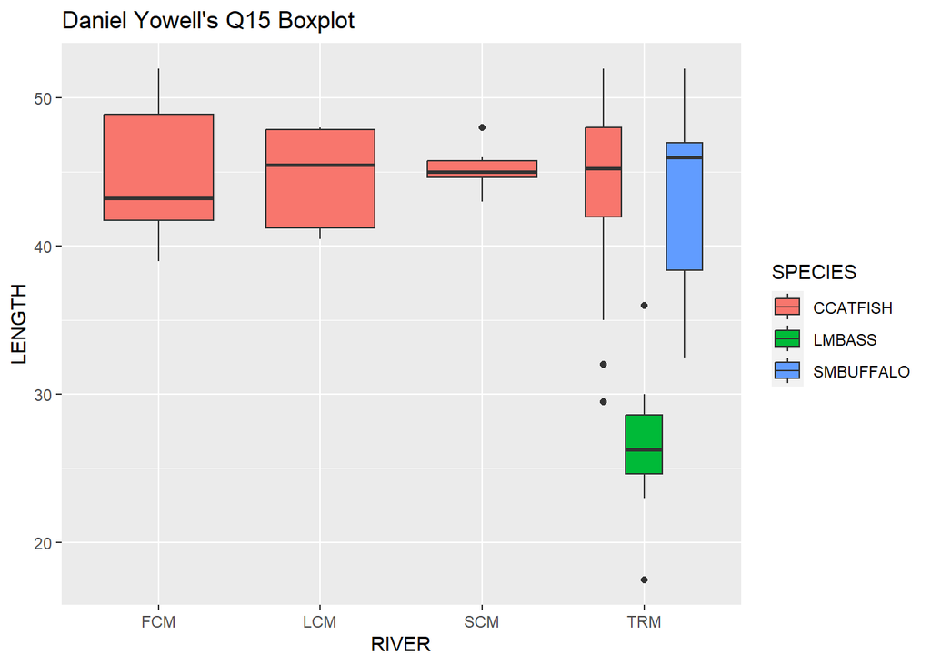

```r
library(ggplot2)
ggplot(ddt, aes(x = RIVER, y = LENGTH, fill = SPECIES)) + geom_boxplot() + ggtitle("Daniel Yowell's Q15 Boxplot")
```